# NCAA Tournament Bracket Prediction

Bracket Model

2026-03-19

# Overview

This report applies a probabilistic modeling framework to predict every game of the NCAA Tournament. Win probabilities are estimated using a logistic function applied to adjusted efficiency margins (AdjEM = AdjO − AdjDef, source: BartTorvik T-Rank). The tournament is then simulated 100,000 times via Monte Carlo methods to estimate each team’s probability of advancing through every round.

# Data

All 64 Tournament Teams with Efficiency Ratings

| Region | Seed | Team | AdjO | AdjDef | AdjEM |
| --- | --- | --- | --- | --- | --- |
| East | 1 | Duke | 128.1 | 90.7 | 37.4 |
|  | 2 | Connecticut | 123.0 | 94.9 | 28.1 |
|  | 3 | Michigan State | 122.9 | 96.1 | 26.8 |
|  | 4 | Kansas | 117.7 | 94.3 | 23.4 |
|  | 5 | Saint John’s | 119.7 | 94.0 | 25.7 |
|  | 6 | Louisville | 124.0 | 98.1 | 25.9 |
|  | 7 | California Los Angeles | 124.5 | 101.7 | 22.8 |
|  | 8 | Ohio State | 125.1 | 101.5 | 23.6 |
|  | 9 | Texas Christian | 114.8 | 99.5 | 15.3 |
|  | 10 | Central Florida | 119.9 | 105.6 | 14.3 |
|  | 11 | South Florida | 116.7 | 101.3 | 15.4 |
|  | 12 | Northern Iowa | 109.7 | 98.5 | 11.2 |
|  | 13 | California Baptist | 107.4 | 100.2 | 7.2 |
|  | 14 | North Dakota State | 111.3 | 106.0 | 5.3 |
|  | 15 | Furman | 106.8 | 109.0 | -2.2 |
|  | 16 | Siena | 107.0 | 108.9 | -1.9 |
| Midwest | 1 | Michigan | 127.6 | 90.9 | 36.7 |
|  | 2 | Iowa State | 123.7 | 92.5 | 31.2 |
|  | 3 | Virginia | 122.3 | 95.8 | 26.5 |
|  | 4 | Alabama | 129.5 | 102.7 | 26.8 |
|  | 5 | Texas Tech | 126.2 | 98.7 | 27.5 |
|  | 6 | Tennessee | 121.4 | 95.4 | 26.0 |
|  | 7 | Kentucky | 119.9 | 99.9 | 20.0 |
|  | 8 | Georgia | 124.4 | 104.7 | 19.7 |
|  | 9 | Saint Louis | 119.4 | 102.2 | 17.2 |
|  | 10 | Santa Clara | 125.0 | 103.7 | 21.3 |
|  | 11 | Miami (OH) | 116.6 | 107.5 | 9.1 |
|  | 12 | Akron | 117.1 | 105.3 | 11.8 |
|  | 13 | Hofstra | 113.1 | 104.8 | 8.3 |
|  | 14 | Wright State | 112.2 | 108.9 | 3.3 |
|  | 15 | Tennessee State | 107.7 | 111.7 | -4.0 |
|  | 16 | Howard | 104.4 | 106.7 | -2.3 |
| South | 1 | Florida | 126.0 | 92.2 | 33.8 |
|  | 2 | Houston | 125.2 | 92.3 | 32.9 |
|  | 3 | Illinois | 131.9 | 98.1 | 33.8 |
|  | 4 | Nebraska | 117.1 | 93.4 | 23.7 |
|  | 5 | Vanderbilt | 127.4 | 99.3 | 28.1 |
|  | 6 | North Carolina | 121.3 | 99.9 | 21.4 |
|  | 7 | Saint Mary’s | 119.4 | 97.5 | 21.9 |
|  | 8 | Clemson | 116.5 | 96.9 | 19.6 |
|  | 9 | Iowa | 122.1 | 100.1 | 22.0 |
|  | 10 | Texas A&M | 119.8 | 101.4 | 18.4 |
|  | 11 | Virginia Commonwealth | 119.2 | 103.0 | 16.2 |
|  | 12 | McNeese | 113.1 | 102.0 | 11.1 |
|  | 13 | Troy | 110.6 | 108.9 | 1.7 |
|  | 14 | Pennsylvania | 106.4 | 105.4 | 1.0 |
|  | 15 | Idaho | 108.7 | 106.1 | 2.6 |
|  | 16 | Prairie View A&M | 101.2 | 110.5 | -9.3 |
| West | 1 | Arizona | 126.8 | 91.3 | 35.5 |
|  | 2 | Purdue | 133.3 | 100.1 | 33.2 |
|  | 3 | Gonzaga | 120.3 | 93.9 | 26.4 |
|  | 4 | Arkansas | 127.9 | 101.5 | 26.4 |
|  | 5 | Wisconsin | 127.1 | 101.5 | 25.6 |
|  | 6 | Brigham Young | 124.7 | 104.2 | 20.5 |
|  | 7 | Miami (FL) | 121.0 | 101.4 | 19.6 |
|  | 8 | Villanova | 119.5 | 100.5 | 19.0 |
|  | 9 | Utah State | 123.1 | 102.0 | 21.1 |
|  | 10 | Missouri | 119.9 | 103.0 | 16.9 |
|  | 11 | Texas | 123.2 | 105.4 | 17.8 |
|  | 12 | High Point | 115.6 | 107.4 | 8.2 |
|  | 13 | Hawaii | 106.7 | 101.8 | 4.9 |
|  | 14 | Kennesaw State | 110.8 | 109.3 | 1.5 |
|  | 15 | Queens | 114.6 | 117.0 | -2.4 |
|  | 16 | Long Island | 103.5 | 109.8 | -6.3 |

# Probabilistic Model

Win probability follows a logistic function on the efficiency margin difference:

$$P(\text{win}) = \frac{1}{1 + \exp(-(E_1
- E_2) / \sigma)}$$

where $\sigma$ is a scaling parameter calibrated to historical NCAA tournament data. We use $\sigma = 10$, which is consistent with published estimates from KenPom-based models.

## Win Probability Preview

Model Win Probabilities vs. Historical Upset Rates

| Matchup | Model P(Higher Seed Wins) | Historical Upset Rate (%) |
| --- | --- | --- |
| 1 vs 16 | 98.3 | NA |
| 2 vs 15 | 96.4 | 7 |
| 3 vs 14 | 92.8 | 15 |
| 4 vs 13 | 87.6 | 21 |
| 5 vs 12 | 83.4 | 35 |
| 6 vs 11 | 70.7 | 37 |
| 7 vs 10 | 58.3 | 40 |
| 8 vs 9 | 53.9 | 50 |

# Monte Carlo Simulation

The tournament bracket is structured with 4 regions of 16 teams. Within each region, the standard NCAA slot pairing applies:

- Round of 64: (1v16), (8v9), (5v12), (4v13), (6v11), (3v14), (7v10), (2v15)
- Winners advance through region to a Final Four
- Final Four: East vs. West, South vs. Midwest (semifinal pairings)
- Championship: Final Four winners meet

# Simulation Results

## Advancement Probabilities by Team

Advancement Probabilities (1e+05 simulations)

| Region | Seed | Team | Rd of 32 | Sweet 16 | Elite 8 | Final Four | Finals | Champion |
| --- | --- | --- | --- | --- | --- | --- | --- | --- |
| East | 1 | Duke | 98.1% | 81.4% | 64.7% | 48.6% | 30.9% | 19.0% |
|  | 2 | Connecticut | 95.5% | 65.0% | 36.9% | 14.5% | 6.0% | 2.3% |
|  | 3 | Michigan State | 89.3% | 52.1% | 27.5% | 10.1% | 4.0% | 1.4% |
|  | 4 | Kansas | 83.6% | 42.0% | 10.9% | 4.6% | 1.4% | 0.4% |
|  | 5 | Saint John’s | 81.1% | 49.5% | 15.0% | 7.4% | 2.7% | 0.9% |
|  | 6 | Louisville | 74.0% | 38.6% | 19.6% | 6.9% | 2.6% | 0.9% |
|  | 7 | California Los Angeles | 70.1% | 27.7% | 12.1% | 3.5% | 1.0% | 0.3% |
|  | 8 | Ohio State | 69.5% | 15.0% | 7.5% | 3.3% | 1.0% | 0.3% |
|  | 9 | Texas Christian | 30.5% | 3.4% | 1.1% | 0.3% | 0.1% | 0.0% |
|  | 10 | Central Florida | 29.9% | 6.9% | 1.7% | 0.3% | 0.0% | 0.0% |
|  | 11 | South Florida | 26.0% | 7.7% | 2.0% | 0.4% | 0.1% | 0.0% |
|  | 12 | Northern Iowa | 18.9% | 5.4% | 0.6% | 0.1% | 0.0% | 0.0% |
|  | 13 | California Baptist | 16.4% | 3.0% | 0.2% | 0.0% | 0.0% | 0.0% |
|  | 14 | North Dakota State | 10.7% | 1.6% | 0.2% | 0.0% | 0.0% | 0.0% |
|  | 15 | Furman | 4.5% | 0.4% | 0.0% | 0.0% | 0.0% | 0.0% |
|  | 16 | Siena | 1.9% | 0.1% | 0.0% | 0.0% | 0.0% | 0.0% |
| Midwest | 1 | Michigan | 98.0% | 84.0% | 61.9% | 43.2% | 26.6% | 15.7% |
|  | 2 | Iowa State | 97.1% | 72.3% | 45.8% | 21.3% | 10.5% | 4.8% |
|  | 3 | Virginia | 91.1% | 51.3% | 23.4% | 8.5% | 3.2% | 1.1% |
|  | 4 | Alabama | 86.2% | 46.7% | 15.7% | 7.5% | 2.9% | 1.0% |
|  | 5 | Texas Tech | 82.5% | 46.6% | 16.5% | 8.2% | 3.3% | 1.2% |
|  | 6 | Tennessee | 84.6% | 44.5% | 19.7% | 7.1% | 2.6% | 0.9% |
|  | 7 | Kentucky | 46.8% | 12.1% | 4.4% | 1.1% | 0.3% | 0.1% |
|  | 8 | Georgia | 56.0% | 9.5% | 3.2% | 1.0% | 0.2% | 0.1% |
|  | 9 | Saint Louis | 44.0% | 6.3% | 1.9% | 0.5% | 0.1% | 0.0% |
|  | 10 | Santa Clara | 53.2% | 15.3% | 6.0% | 1.5% | 0.4% | 0.1% |
|  | 11 | Miami (OH) | 15.4% | 2.9% | 0.4% | 0.1% | 0.0% | 0.0% |
|  | 12 | Akron | 17.5% | 4.2% | 0.5% | 0.1% | 0.0% | 0.0% |
|  | 13 | Hofstra | 13.8% | 2.5% | 0.2% | 0.0% | 0.0% | 0.0% |
|  | 14 | Wright State | 8.9% | 1.2% | 0.1% | 0.0% | 0.0% | 0.0% |
|  | 15 | Tennessee State | 2.9% | 0.2% | 0.0% | 0.0% | 0.0% | 0.0% |
|  | 16 | Howard | 2.0% | 0.2% | 0.0% | 0.0% | 0.0% | 0.0% |
| South | 1 | Florida | 98.7% | 77.1% | 53.2% | 29.3% | 16.0% | 8.3% |
|  | 2 | Houston | 95.4% | 73.9% | 40.3% | 23.0% | 12.1% | 6.1% |
|  | 3 | Illinois | 96.4% | 77.6% | 46.1% | 27.2% | 14.8% | 7.7% |
|  | 4 | Nebraska | 90.1% | 40.7% | 13.8% | 4.4% | 1.4% | 0.4% |
|  | 5 | Vanderbilt | 84.5% | 54.2% | 23.4% | 9.6% | 3.9% | 1.5% |
|  | 6 | North Carolina | 62.9% | 15.5% | 4.8% | 1.5% | 0.4% | 0.1% |
|  | 7 | Saint Mary’s | 58.8% | 16.5% | 5.0% | 1.6% | 0.5% | 0.1% |
|  | 8 | Clemson | 43.8% | 9.0% | 3.3% | 0.8% | 0.2% | 0.0% |
|  | 9 | Iowa | 56.2% | 13.8% | 5.7% | 1.6% | 0.4% | 0.1% |
|  | 10 | Texas A&M | 41.2% | 9.0% | 2.2% | 0.6% | 0.1% | 0.0% |
|  | 11 | Virginia Commonwealth | 37.1% | 6.4% | 1.4% | 0.3% | 0.1% | 0.0% |
|  | 12 | McNeese | 15.5% | 4.2% | 0.6% | 0.1% | 0.0% | 0.0% |
|  | 13 | Troy | 9.9% | 0.9% | 0.1% | 0.0% | 0.0% | 0.0% |
|  | 14 | Pennsylvania | 3.6% | 0.5% | 0.0% | 0.0% | 0.0% | 0.0% |
|  | 15 | Idaho | 4.6% | 0.7% | 0.1% | 0.0% | 0.0% | 0.0% |
|  | 16 | Prairie View A&M | 1.3% | 0.1% | 0.0% | 0.0% | 0.0% | 0.0% |
| West | 1 | Arizona | 98.5% | 81.0% | 59.0% | 38.3% | 22.7% | 12.9% |
|  | 2 | Purdue | 97.2% | 79.1% | 56.5% | 30.9% | 16.8% | 8.6% |
|  | 3 | Gonzaga | 92.3% | 61.7% | 25.5% | 9.9% | 3.8% | 1.3% |
|  | 4 | Arkansas | 89.6% | 51.1% | 18.4% | 8.1% | 3.1% | 1.1% |
|  | 5 | Wisconsin | 85.2% | 44.5% | 15.1% | 6.3% | 2.3% | 0.8% |
|  | 6 | Brigham Young | 56.9% | 22.7% | 6.6% | 1.7% | 0.5% | 0.1% |
|  | 7 | Miami (FL) | 56.7% | 12.7% | 5.2% | 1.3% | 0.3% | 0.1% |
|  | 8 | Villanova | 44.9% | 7.8% | 2.8% | 0.8% | 0.2% | 0.0% |
|  | 9 | Utah State | 55.1% | 11.1% | 4.4% | 1.5% | 0.4% | 0.1% |
|  | 10 | Missouri | 43.3% | 7.9% | 2.7% | 0.6% | 0.1% | 0.0% |
|  | 11 | Texas | 43.1% | 14.5% | 3.5% | 0.7% | 0.2% | 0.0% |
|  | 12 | High Point | 14.8% | 2.8% | 0.2% | 0.0% | 0.0% | 0.0% |
|  | 13 | Hawaii | 10.4% | 1.6% | 0.1% | 0.0% | 0.0% | 0.0% |
|  | 14 | Kennesaw State | 7.7% | 1.1% | 0.1% | 0.0% | 0.0% | 0.0% |
|  | 15 | Queens | 2.8% | 0.3% | 0.0% | 0.0% | 0.0% | 0.0% |
|  | 16 | Long Island | 1.5% | 0.1% | 0.0% | 0.0% | 0.0% | 0.0% |

## Championship Contenders

Top Championship Contenders

| Team | Seed | Region | Final Four | Finals | Champion |
| --- | --- | --- | --- | --- | --- |
| Duke | 1 | East | 48.6% | 30.9% | 19.0% |
| Michigan | 1 | Midwest | 43.2% | 26.6% | 15.7% |
| Arizona | 1 | West | 38.3% | 22.7% | 12.9% |
| Purdue | 2 | West | 30.9% | 16.8% | 8.6% |
| Florida | 1 | South | 29.3% | 16.0% | 8.3% |
| Illinois | 3 | South | 27.2% | 14.8% | 7.7% |
| Houston | 2 | South | 23.0% | 12.1% | 6.1% |
| Iowa State | 2 | Midwest | 21.3% | 10.5% | 4.8% |
| Connecticut | 2 | East | 14.5% | 6.0% | 2.3% |
| Vanderbilt | 5 | South | 9.6% | 3.9% | 1.5% |
| Michigan State | 3 | East | 10.1% | 4.0% | 1.4% |
| Gonzaga | 3 | West | 9.9% | 3.8% | 1.3% |
| Texas Tech | 5 | Midwest | 8.2% | 3.3% | 1.2% |
| Virginia | 3 | Midwest | 8.5% | 3.2% | 1.1% |
| Arkansas | 4 | West | 8.1% | 3.1% | 1.1% |
| Alabama | 4 | Midwest | 7.5% | 2.9% | 1.0% |

## Championship Probability Chart

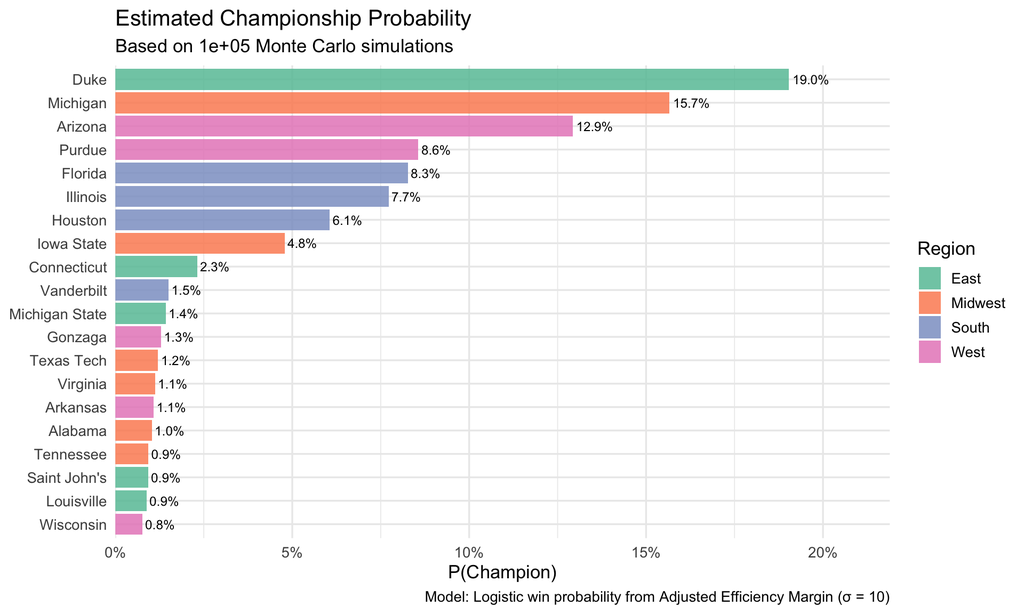

# Most Likely Bracket

The most likely bracket is constructed by selecting the higher-probability team to win each game, working forward from Round 1 through the Championship.

## Round of 64

Round of 64 — Predicted Results

| Region | Team1 | Team2 | P(Team1 Wins) | Predicted_Winner |
| --- | --- | --- | --- | --- |
| East | Duke | Siena | 98.1% | Duke |
|  | Ohio State | Texas Christian | 69.6% | Ohio State |
|  | Saint John’s | Northern Iowa | 81% | Saint John’s |
|  | Kansas | California Baptist | 83.5% | Kansas |
|  | Louisville | South Florida | 74.1% | Louisville |
|  | Michigan State | North Dakota State | 89.6% | Michigan State |
|  | California Los Angeles | Central Florida | 70.1% | California Los Angeles |
|  | Connecticut | Furman | 95.4% | Connecticut |
| South | Florida | Prairie View A&M | 98.7% | Florida |
|  | Clemson | Iowa | 44% | Iowa |
|  | Vanderbilt | McNeese | 84.6% | Vanderbilt |
|  | Nebraska | Troy | 90% | Nebraska |
|  | North Carolina | Virginia Commonwealth | 62.7% | North Carolina |
|  | Illinois | Pennsylvania | 96.4% | Illinois |
|  | Saint Mary’s | Texas A&M | 58.7% | Saint Mary’s |
|  | Houston | Idaho | 95.4% | Houston |
| West | Arizona | Long Island | 98.5% | Arizona |
|  | Villanova | Utah State | 44.8% | Utah State |
|  | Wisconsin | High Point | 85.1% | Wisconsin |
|  | Arkansas | Hawaii | 89.6% | Arkansas |
|  | Brigham Young | Texas | 56.7% | Brigham Young |
|  | Gonzaga | Kennesaw State | 92.3% | Gonzaga |
|  | Miami (FL) | Missouri | 56.7% | Miami (FL) |
|  | Purdue | Queens | 97.2% | Purdue |
| Midwest | Michigan | Howard | 98% | Michigan |
|  | Georgia | Saint Louis | 56.2% | Georgia |
|  | Texas Tech | Akron | 82.8% | Texas Tech |
|  | Alabama | Hofstra | 86.4% | Alabama |
|  | Tennessee | Miami (OH) | 84.4% | Tennessee |
|  | Virginia | Wright State | 91.1% | Virginia |
|  | Kentucky | Santa Clara | 46.8% | Santa Clara |
|  | Iowa State | Tennessee State | 97.1% | Iowa State |

## Round of 32

Round of 32 — Predicted Results

| Region | Team1 | Team2 | P(Team1 Wins) | Predicted_Winner |
| --- | --- | --- | --- | --- |
| East | Duke | Ohio State | 79.9% | Duke |
|  | Saint John’s | Kansas | 55.7% | Saint John’s |
|  | Louisville | Michigan State | 47.8% | Michigan State |
|  | California Los Angeles | Connecticut | 37.1% | Connecticut |
| South | Florida | Iowa | 76.5% | Florida |
|  | Vanderbilt | Nebraska | 60.8% | Vanderbilt |
|  | North Carolina | Illinois | 22.4% | Illinois |
|  | Saint Mary’s | Houston | 25% | Houston |
| West | Arizona | Utah State | 80.8% | Arizona |
|  | Wisconsin | Arkansas | 48% | Arkansas |
|  | Brigham Young | Gonzaga | 35.7% | Gonzaga |
|  | Miami (FL) | Purdue | 20.4% | Purdue |
| Midwest | Michigan | Georgia | 84.6% | Michigan |
|  | Texas Tech | Alabama | 51.7% | Texas Tech |
|  | Tennessee | Virginia | 48.8% | Virginia |
|  | Santa Clara | Iowa State | 27.1% | Iowa State |

## Sweet 16

Sweet 16 — Predicted Results

| Region | Team1 | Team2 | P(Team1 Wins) | Predicted_Winner |
| --- | --- | --- | --- | --- |
| East | Duke | Saint John’s | 76.3% | Duke |
|  | Michigan State | Connecticut | 46.8% | Connecticut |
| South | Florida | Vanderbilt | 63.9% | Florida |
|  | Illinois | Houston | 52.2% | Illinois |
| West | Arizona | Arkansas | 71.3% | Arizona |
|  | Gonzaga | Purdue | 33.6% | Purdue |
| Midwest | Michigan | Texas Tech | 71.5% | Michigan |
|  | Virginia | Iowa State | 38.5% | Iowa State |

## Elite Eight

Elite Eight — Predicted Results

| Region | Team1 | Team2 | P(Team1 Wins) | Predicted_Winner |
| --- | --- | --- | --- | --- |
| East | Duke | Connecticut | 71.7% | Duke |
| South | Florida | Illinois | 50% | Illinois |
| West | Arizona | Purdue | 55.7% | Arizona |
| Midwest | Michigan | Iowa State | 63.4% | Michigan |

## Final Four

Final Four — Predicted Results

| Semifinal | Team1 | Team2 | P(Team1 Wins) | Predicted_Winner |
| --- | --- | --- | --- | --- |
| East vs West | Duke | Arizona | 54.7% | Duke |
| South vs Midwest | Illinois | Michigan | 42.8% | Michigan |

## Championship

National Championship Game

| Team1 | Team2 | P(Team1 Wins) | Predicted Champion |
| --- | --- | --- | --- |
| Duke | Michigan | 51.7% | Duke |

# Game Theory: Strategic Upset Selection

Using the expected value framework from the document:

$$EV = P \times V \times (1 -
O)$$

where $P$ = probability of upset, $V$ = point value of the round, $O$ = fraction of brackets selecting the upset.

For this analysis we approximate ownership using seed-based priors (popular upsets like 12-over-5 have ~50% ownership; unlikely ones are much lower).

Top 15 Round of 64 Upset Opportunities by Expected Value

| Favorite | Underdog | P(Upset) | Ownership (est.) | EV (Round of 64) |
| --- | --- | --- | --- | --- |
| Kentucky | Santa Clara | 0.532 | 0.35 | 0.346 |
| Clemson | Iowa | 0.560 | 0.45 | 0.308 |
| Villanova | Utah State | 0.552 | 0.45 | 0.304 |
| Miami (FL) | Missouri | 0.433 | 0.35 | 0.281 |
| Saint Mary’s | Texas A&M | 0.413 | 0.35 | 0.269 |
| Georgia | Saint Louis | 0.438 | 0.45 | 0.241 |
| Brigham Young | Texas | 0.433 | 0.45 | 0.238 |
| North Carolina | Virginia Commonwealth | 0.373 | 0.45 | 0.205 |
| California Los Angeles | Central Florida | 0.299 | 0.35 | 0.195 |
| Ohio State | Texas Christian | 0.304 | 0.45 | 0.167 |
| Louisville | South Florida | 0.259 | 0.45 | 0.143 |
| Kansas | California Baptist | 0.165 | 0.15 | 0.140 |
| Alabama | Hofstra | 0.136 | 0.15 | 0.115 |
| Saint John’s | Northern Iowa | 0.190 | 0.48 | 0.099 |
| Michigan State | North Dakota State | 0.104 | 0.10 | 0.094 |

# Summary

```
## === PREDICTED BRACKET SUMMARY ===
```

```
## FINAL FOUR:
```

```
##  • Duke
##  • Illinois
##  • Arizona
##  • Michigan
```

```
##
## CHAMPIONSHIP GAME:
##  • Duke vs. Michigan
```

```
##
## PREDICTED CHAMPION:
##  • Duke
```

```
## TOP CHAMPIONSHIP PROBABILITIES (from simulation):
```

```
##  1. Duke (East, Seed 1): 19.0%
##  2. Michigan (Midwest, Seed 1): 15.7%
##  3. Arizona (West, Seed 1): 12.9%
##  4. Purdue (West, Seed 2): 8.6%
##  5. Florida (South, Seed 1): 8.3%
```

*Model based on logistic win probability from Adjusted Efficiency Margin. Simulation: 1e+05 iterations. σ = 10.*